# Tarea 16

Martin Santamaria

6/12/2020

### Ejercicio 1

#### Datos

```r
altura = c(0.4826,0.5588,0.6350,0.7874,0.8382,0.9906,1.1176,1.1430)
lluvia = c(0.2540,0.3556,0.4572,0.5588,0.6604,0.7620,0.8636,0.9652)
tabla.reg = data.frame(altura,lluvia)
k=1
n=nrow(tabla.reg)

reg.lineal.simple = lm(altura~lluvia,data=tabla.reg)
reg.lineal.simple.summary = summary(reg.lineal.simple)
```

#### a)

Determinamos la recta $\hat{y} = b_0 + b_1x$ donde $x$ es la cantidad de lluvia en $m^3$ por año

```r
b_0 = reg.lineal.simple$coefficients[1]
b_1 = reg.lineal.simple$coefficients[2]
```

$\hat{y} = 0.20955 + x$

#### b)

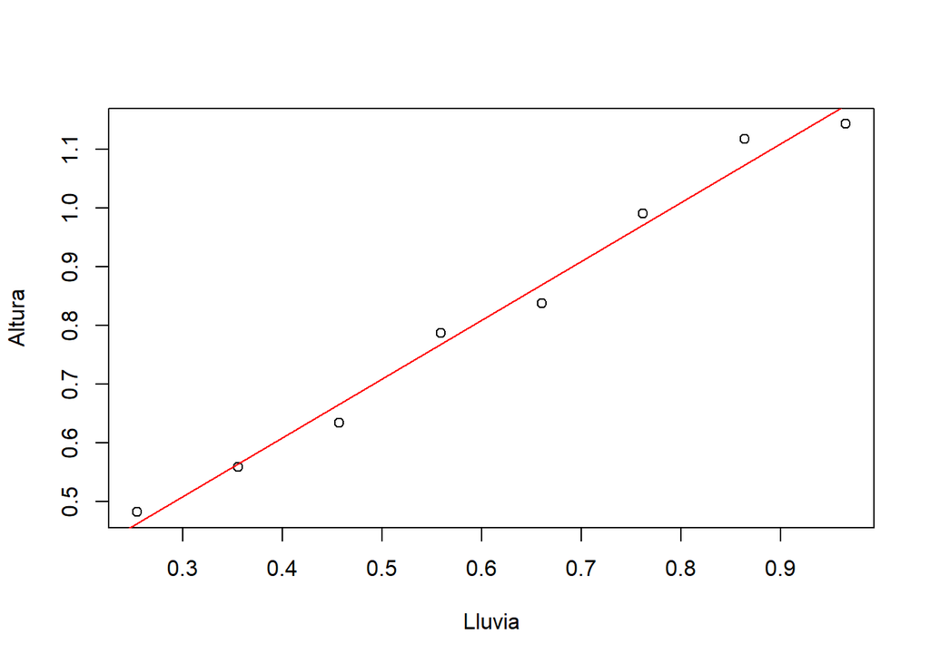

```r
plot(altura~lluvia,data=tabla.reg,xlab="Lluvia",ylab="Altura")
abline(reg.lineal.simple,col="red")
```

Podemos estudiar la linealidad del modelo con el siguiente gráfico

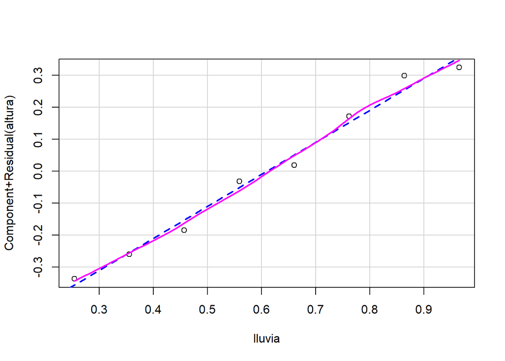

```r
crPlots(reg.lineal.simple)
```

#### c)

```r
I.C = confint(reg.lineal.simple,level=0.95)
```

Intervalo de confianza al $95 \%$ para el parámetro $\beta_0$

$(0.132,0.287)$

Intervalo de confianza al $95 \%$ para el parámetro $\beta_1$

$(0.881,1.119)$

#### d)

Un estimador no sesgado de $\sigma_E^2$ es el siguiente: $S^2=\frac{\displaystyle \sum_{i=1}^{n} e^2_i}{n-k-1}$ siendo $k=1$

```r
var_e = sum(reg.lineal.simple$residuals^2)/(n-k-1)
```

Por tanto $\sigma_E^2 = 0.0010215$

También se puede hallar de la siguiente manera

```r
var_e = reg.lineal.simple.summary$sigma^2
```

$\sigma_E^2 = 0.0010215$

#### e)

```r
r2 = reg.lineal.simple.summary$r.squared
r2.adj = reg.lineal.simple.summary$adj.r.squared
```

$R^2 = 0.9860602$

$R^2_{adj} = 0.9837369$

Los valores son altos indicando que la linealidad del modelo es buena.

#### f)

Realizamos un gráfico de los residuos en función de los valores estimados

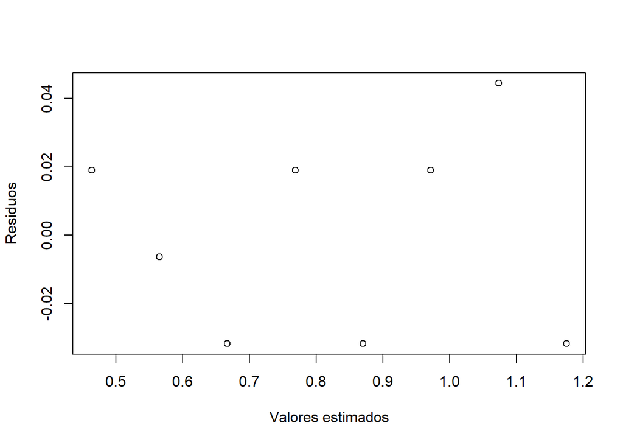

```r
plot(x=reg.lineal.simple$fitted.values,
     y=reg.lineal.simple$residuals,
     xlab="Valores estimados",
     ylab="Residuos")
```

El gráfico tiene pinta de cielo estrellado, por tanto podríamos concluir que el modelo es homocedástico. Sin embargo, veamoslo mejor realizando un test de **Breusch-Pagan**

```r
bptest(reg.lineal.simple)
```

```
##
##  studentized Breusch-Pagan test
##
## data:  reg.lineal.simple
## BP = 2.9879, df = 1, p-value = 0.08389
```

El p-valor obtenido nos coloca en la zona de penumbra. Veamos si podemos realizar un test de **White**. En primer lugar tenemos que el tamaño de la muestra de los errores es $8$ y el número de variables independientes auxiliares es $2$ dado que son $x_1$ y $x_1^2$. Como tenemos que el tamaño de los valores de los errores es mayor que el de las variables independientes, entonces podemos realizar el test de White

```r
bptest(reg.lineal.simple,~lluvia+I(lluvia^2))
```

```
##
##  studentized Breusch-Pagan test
##
## data:  reg.lineal.simple
## BP = 2.9953, df = 2, p-value = 0.2237
```

Con el p-valor obtenido concluimos que los residuos son homocedásticos.

#### g)

Para estudiar la normalidad de los residuos realizamos un test de **Shapiro-Wilks**

```r
shapiro.test(reg.lineal.simple$residuals)
```

```
##
##  Shapiro-Wilk normality test
##
## data:  reg.lineal.simple$residuals
## W = 0.8577, p-value = 0.1139
```

El p-valor obtenido nos indica que los residuos siguen una distribución normal. También podemos verlo realizando un **qqplot** teniendo en cuenta que los residuos tienen una distribución $N(0,S)$ donde $S = \sqrt{\frac{\displaystyle \sum_{i=1}^{n} e^2_i}{n-k-1}}$ siendo $k=1$

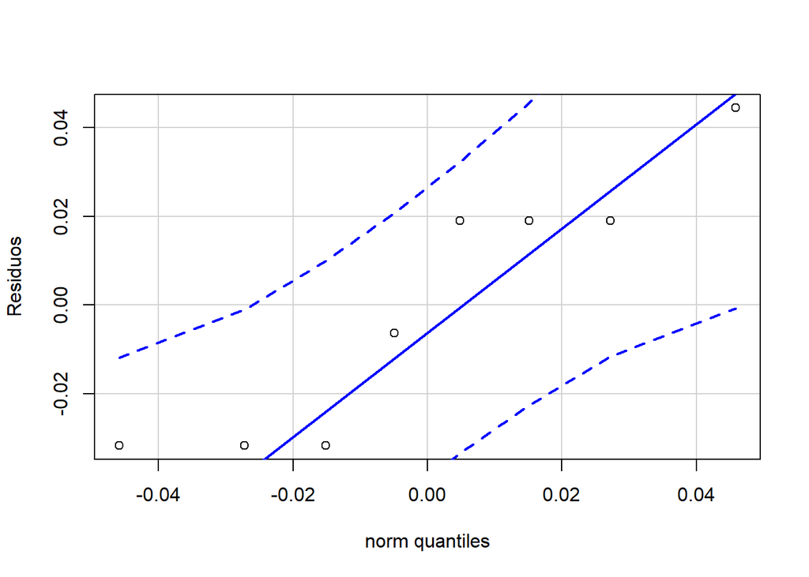

```r
qqPlot(reg.lineal.simple$residuals,
       distribution="norm",
       mean=0,sd=reg.lineal.simple.summary$sigma,
       ylab="Residuos",
       id = FALSE)
```

Se observa claramente en el gráfico como los valores están dentro de la banda de confianza afirmando la distribución normal de los mismos.

#### h)

Aplicaremos el test de **Durbin-Watson** para estudiar la correlación de los errores

```r
dwtest(reg.lineal.simple,alternative = 'two.sided')
```

```
##
##  Durbin-Watson test
##
## data:  reg.lineal.simple
## DW = 2.5263, p-value = 0.7406
## alternative hypothesis: true autocorrelation is not 0
```

El p-valor grande obtenido nos indica que los datos están incorrelados

#### i)

Por último pasemos a observar los **outliers**, **leverages** y **observaciones influyentes**

- **Observaciones influyentes**

```r
distancias.cook=cooks.distance(reg.lineal.simple)
which(distancias.cook > 4/(n-k-1))
```

```
## named integer(0)
```

No tenemos observaciones influyentes que afecten a la regresión

- **Outliers**

```r
outlierTest(reg.lineal.simple)
```

```
## No Studentized residuals with Bonferroni p < 0.05
## Largest |rstudent|:
##   rstudent unadjusted p-value Bonferroni p
## 7 1.997865            0.10222      0.81774
```

El valor $7$ es un posible outlier. Sin embargo, descartamos que sea un outlier dado el p-valor ajustado obtenido del test de **Bonferroni**

- **Leverages**

```r
valores.hat=hatvalues(reg.lineal.simple)
which(valores.hat > 2*(k+1)/n)
```

```
## named integer(0)
```

Y por último, tampoco tenemos observaciones “leverage”.

### Ejercicio 2

#### Datos

```r
biomasa = c(16.6,49.1,121.7,219.6,375.5,570.8,648.2,755.6)
radiacion = c(29.7,68.4,120.7,217.2,313.5,419.1,535.9,641.5)
tabla.reg = data.frame(biomasa,radiacion)
k=1
n=nrow(tabla.reg)

reg.lineal.simple = lm(biomasa~radiacion,data=tabla.reg)
reg.lineal.simple.summary = summary(reg.lineal.simple)
```

#### a)

Determinamos la recta $\hat{y} = b_0 + b_1x$ donde $x$ es la cantidad de radiación solar acumulada durante un período de ocho semanas

```r
b_0 = reg.lineal.simple$coefficients[1]
b_1 = reg.lineal.simple$coefficients[2]
```

$\hat{y} = -27.5689519 + 1.2692462x$

#### b)

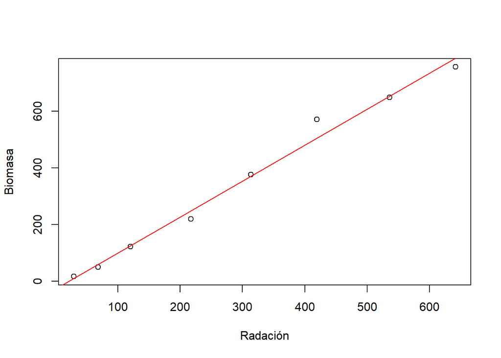

```r
plot(biomasa~radiacion,data=tabla.reg,xlab="Radación",ylab="Biomasa")
abline(reg.lineal.simple,col="red")
```

Podemos estudiar la linealidad del modelo con el siguiente gráfico

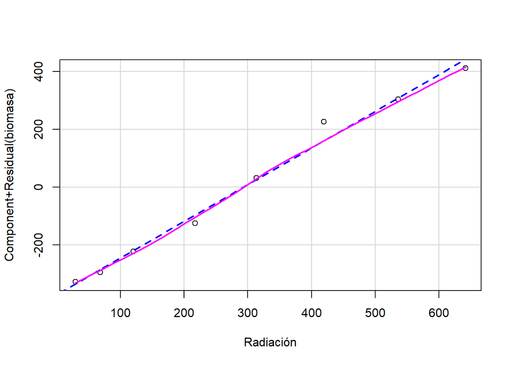

```r
crPlots(reg.lineal.simple,xlab="Radiación")
```

#### c)

```r
I.C = confint(reg.lineal.simple,level=0.95)
```

Intervalo de confianza al $95 \%$ para el parámetro $\beta_0$

$(-76.121,20.983)$

Intervalo de confianza al $95 \%$ para el parámetro $\beta_1$

$(1.135,1.404)$

#### d)

Un estimador no sesgado de $\sigma_E^2$ es el siguiente: $S^2=\frac{\displaystyle \sum_{i=1}^{n} e^2_i}{n-k-1}$ siendo $k=1$

```r
var_e = sum(reg.lineal.simple$residuals^2)/(n-k-1)
```

Por tanto $\sigma_E^2 = 1066.0466662$

También se puede hallar de la siguiente manera

```r
var_e = reg.lineal.simple.summary$sigma^2
```

$\sigma_E^2 = 1066.0466662$

#### e)

```r
r2 = reg.lineal.simple.summary$r.squared
r2.adj = reg.lineal.simple.summary$adj.r.squared
```

$R^2 = 0.9888456$

$R^2_{adj} = 0.9869865$

Los valores son altos indicando que la linealidad del modelo es buena.

#### f)

Realizamos un gráfico de los residuos en función de los valores estimados

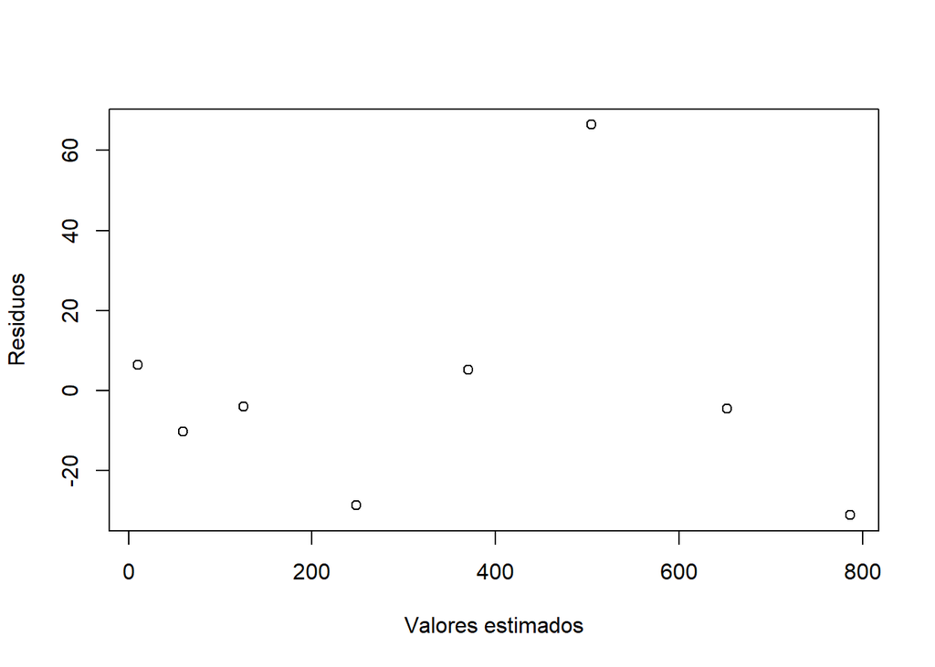

```r
plot(x=reg.lineal.simple$fitted.values,
     y=reg.lineal.simple$residuals,
     xlab="Valores estimados",
     ylab="Residuos")
```

El gráfico no tiene pinta de cielo estrellado, al menos no tan evidente. Estudiemos la homocedasticidad realizando un test de **Breusch-Pagan**

```r
bptest(reg.lineal.simple)
```

```
##
##  studentized Breusch-Pagan test
##
## data:  reg.lineal.simple
## BP = 0.90618, df = 1, p-value = 0.3411
```

Con el p-valor obtenido concluimos que los residuos son homocedásticos.

#### g)

Para estudiar la normalidad de los residuos realizamos un test de **Shapiro-Wilks**

```r
shapiro.test(reg.lineal.simple$residuals)
```

```
##
##  Shapiro-Wilk normality test
##
## data:  reg.lineal.simple$residuals
## W = 0.82756, p-value = 0.056
```

El p-valor obtenido nos coloca en la zona de penumbra. Realicemos un **qqplot** teniendo en cuenta que los residuos tienen distribución $N(0,S)$ donde $S = \sqrt{\frac{\displaystyle \sum_{i=1}^{n} e^2_i}{n-k-1}}$ siendo $k=1$

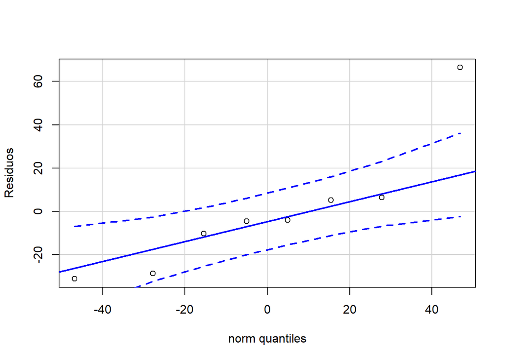

```r
qqPlot(reg.lineal.simple$residuals,
       distribution="norm",
       mean=0,sd=reg.lineal.simple.summary$sigma,
       ylab="Residuos",
       id = FALSE)
```

Se observa claramente en el gráfico como los valores están dentro de la banda de confianza, salvo uno de los valores más extremos que queda por fuera dando a entender el porqué del p-valor apenas por encima de $0.05$ obtenido anteriormente. Podríamos decir que los errores siguen una distribución normal con un nivel de significación $\alpha = 0.05$. Realicemos un test de **Anderson-Darling (A-D)** a ver si podemos echar un poco más de luz al asunto

```r
ad.test(reg.lineal.simple$residuals)
```

```
##
##  Anderson-Darling normality test
##
## data:  reg.lineal.simple$residuals
## A = 0.62527, p-value = 0.06543
```

Obtenemos un p-valor algo superior que con el test de Shapiro-Wilks. Afirmamos la distribución normal de los residuos apoyandonos tanto en el gráfico como en los dos test de normalidad realizados.

#### h)

Aplicaremos el test de **Durbin-Watson** para estudiar la correlación de los errores

```r
dwtest(reg.lineal.simple,alternative = 'two.sided')
```

```
##
##  Durbin-Watson test
##
## data:  reg.lineal.simple
## DW = 1.8035, p-value = 0.4116
## alternative hypothesis: true autocorrelation is not 0
```

El p-valor obtenido nos indica que los datos están incorrelados

#### i)

Por último pasemos a observar los **outliers**, **leverages** y **observaciones influyentes**

- **Observaciones influyentes**

```r
distancias.cook=cooks.distance(reg.lineal.simple)
which(distancias.cook > 4/(n-k-1))
```

```
## 8
## 8
```

El valor número $8$ es una observación influyente.

- **Outliers**

```r
outlierTest(reg.lineal.simple)
```

```
##   rstudent unadjusted p-value Bonferroni p
## 6 4.961544          0.0042425      0.03394
```

El valor $6$ es un posible outlier. El p-valor ajustado obtenido del test de **Bonferroni** menor que $0.05$ nos afirma que justamente es un outlier

- **Leverages**

```r
valores.hat=hatvalues(reg.lineal.simple)
which(valores.hat > 2*(k+1)/n)
```

```
## named integer(0)
```

Por último, no tenemos observaciones “leverage”.

### Ejercicio 3

#### Datos

```r
Q_0 = c(28,112,398,772,2294,2484,2586,3024,4179,710)
Q_p = c(32,142,502,790,3075,3230,3535,4265,6529,935)
X_1 = c(.03,.03,.13,1.00,1.00,3.00,5.00,7.00,7.00,7.00)
X_2 = c(3.0,3.0,6.5,15.0,15.0,7.0,6.0,6.5,6.5,6.5)
X_3 = c(70,80,65,60,65,67,62,56,56,56)
X_4 = c(.6,1.8,2.0,.4,2.3,1.0,.9,1.1,1.4,.7)

Y = log(Q_0 / Q_p)

tabla.reg = data.frame(Y,X_1,X_2,X_3,X_4)
k=4
n=nrow(tabla.reg)

reg.lineal.multiple = lm(Y~X_1+X_2+X_3+X_4,data=tabla.reg)
reg.lineal.multiple.summary = summary(reg.lineal.multiple)
```

#### a)

Determinamos la recta $\hat{y} = b_0 + b_1x_1+b_2x_2+b_3x_3+b_4x_4$ donde

$x_1$ es el área de la cuenca en $m^2$

$x_2$ es la pendiente promedio de la cuenca (en porcentaje)

$x_3$ es el índice de absorbencia superficial (0 = absorbencia completa, 100 = sin absorbencia)

$x_4$ es la intensidad de pico de lluvia calculada en intervalos de media hora

```r
b_0 = reg.lineal.multiple$coefficients[1]
b_1 = reg.lineal.multiple$coefficients[2]
b_2 = reg.lineal.multiple$coefficients[3]
b_3 = reg.lineal.multiple$coefficients[4]
b_4 = reg.lineal.multiple$coefficients[5]
```

$\hat{y} = 0.0873213 -0.0353841x_1 +0.0047262x_2 -0.0019131x_3 -0.12008x_4$

#### b)

```r
I.C = confint(reg.lineal.multiple,level=0.95)
```

Intervalo de confianza al $95 \%$ para el parámetro $\beta_0$

$(-0.715,0.889)$

Intervalo de confianza al $95 \%$ para el parámetro $\beta_1$

$(-0.059,-0.011)$

Intervalo de confianza al $95 \%$ para el parámetro $\beta_2$

$(-0.008,0.017)$

Intervalo de confianza al $95 \%$ para el parámetro $\beta_3$

$(-0.013,0.009)$

Intervalo de confianza al $95 \%$ para el parámetro $\beta_4$

$(-0.181,-0.059)$

#### c)

Un estimador no sesgado de $\sigma_E^2$ es el siguiente: $S^2=\frac{\displaystyle \sum_{i=1}^{n} e^2_i}{n-k-1}$ siendo $k=4$

```r
var_e = sum(reg.lineal.multiple$residuals^2)/(n-k-1)
```

Por tanto $\sigma_E^2 = 0.0016967$

También se puede hallar de la siguiente manera

```r
var_e = reg.lineal.multiple.summary$sigma^2
```

$\sigma_E^2 = 0.0016967$

#### d)

```r
r2 = reg.lineal.multiple.summary$r.squared
r2.adj = reg.lineal.multiple.summary$adj.r.squared
```

$R^2 = 0.9287455$

$R^2_{adj} = 0.8717419$

Los valores son altos indicando que la linealidad del modelo es buena (en realidad el coeficiente de determinación que cuenta es el ajustado).

#### e)

Realizamos un gráfico de los residuos en función de los valores estimados

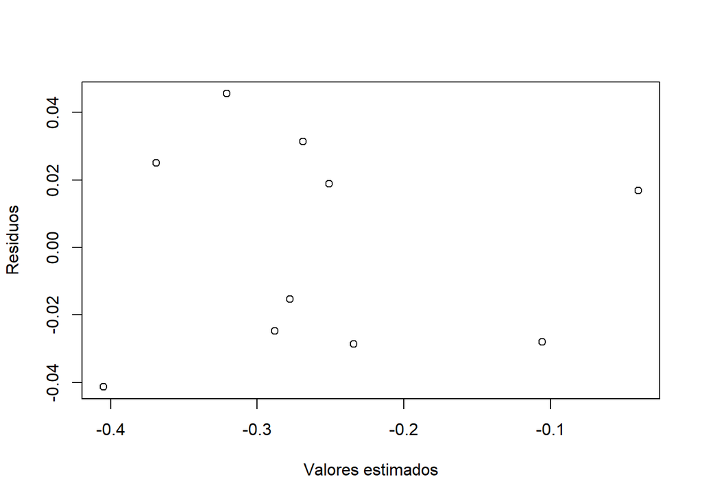

```r
plot(x=reg.lineal.multiple$fitted.values,
     y=reg.lineal.multiple$residuals,
     xlab="Valores estimados",
     ylab="Residuos")
```

El gráfico se podría decir que tiene pinta de cielo estrellado y concluir que los residuos son homocedásticos. Estudiemos la homocedasticidad realizando un test de **Breusch-Pagan**

```r
bptest(reg.lineal.multiple)
```

```
##
##  studentized Breusch-Pagan test
##
## data:  reg.lineal.multiple
## BP = 5.3394, df = 4, p-value = 0.2542
```

Con el p-valor obtenido concluimos que el modelo es homocedástico.

#### f)

Para estudiar la normalidad de los residuos realizamos un test de **Shapiro-Wilks**

```r
shapiro.test(reg.lineal.multiple$residuals)
```

```
##
##  Shapiro-Wilk normality test
##
## data:  reg.lineal.multiple$residuals
## W = 0.90416, p-value = 0.2432
```

El p-valor obtenido nos afirma claramente que los residuos siguen una distribución normal. Realicemos un **qqplot** teniendo en cuenta que los residuos tienen distribución $N(0,S)$ donde $S = \sqrt{\frac{\displaystyle \sum_{i=1}^{n} e^2_i}{n-k-1}}$ siendo $k=4$

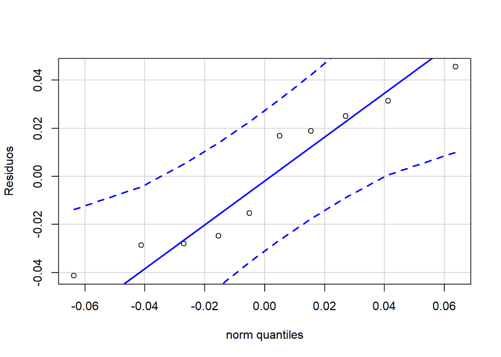

```r
qqPlot(reg.lineal.multiple$residuals,
       distribution="norm",
       mean=0,sd=reg.lineal.multiple.summary$sigma,
       ylab="Residuos",
       id = FALSE)
```

Se observa claramente en el gráfico como los valores están dentro de la banda de confianza. Concluimos que los errores siguen una distribución normal.

#### g)

Aplicaremos el test de **Durbin-Watson** para estudiar la correlación de los residuos

```r
dwtest(reg.lineal.multiple,alternative = 'two.sided')
```

```
##
##  Durbin-Watson test
##
## data:  reg.lineal.multiple
## DW = 2.2785, p-value = 0.9171
## alternative hypothesis: true autocorrelation is not 0
```

El p-valor tremendamente alto obtenido nos indica que los datos están incorrelados.

#### h)

Realicemos un test de **Tukey** para estudiar la aditividad del modelo

```r
residualPlots(reg.lineal.multiple,plot=FALSE)
```

```
##            Test stat Pr(>|Test stat|)
## X_1           1.2725           0.2721
## X_2           0.1202           0.9101
## X_3           1.7156           0.1614
## X_4           0.6508           0.5507
## Tukey test   -0.2150           0.8298
```

El p-valor grande obtenido nos da evidencias para aceptar la aditividad del modelo. Pasemos ahora a estudiar la linealidad del mismo

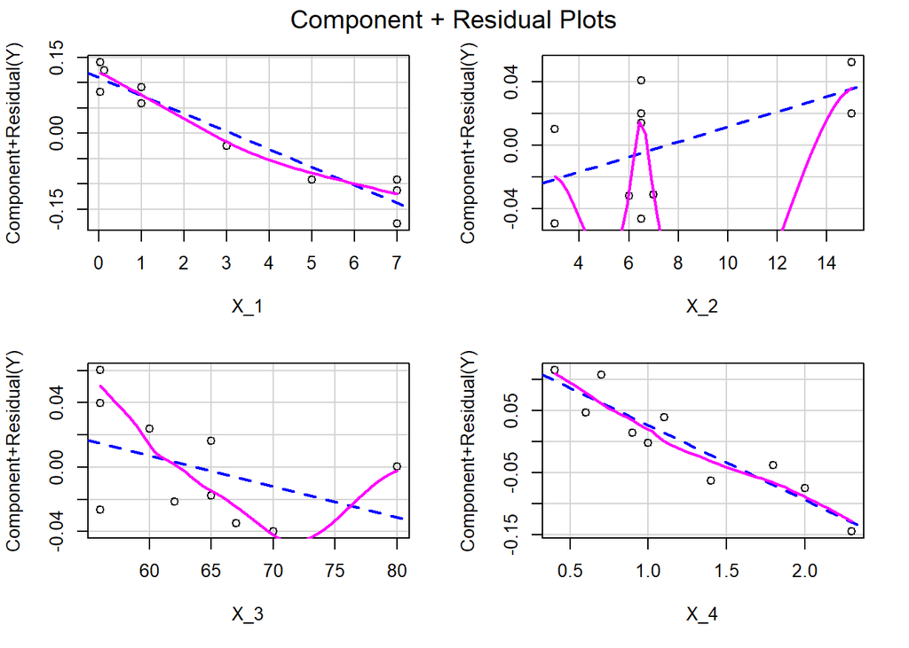

```r
crPlots(reg.lineal.multiple)
```

En los gráficos se observa claramente solo dos variables significativas $x_1$ y $x_4$. Esto nos lleva a realizar una comparación entre modelos. Realicemos esto con la función `step`

```r
step(reg.lineal.multiple)
```

```
## Start:  AIC=-60.72
## Y ~ X_1 + X_2 + X_3 + X_4
##
##        Df Sum of Sq      RSS     AIC
## - X_3   1  0.000354 0.008838 -62.313
## - X_2   1  0.001669 0.010153 -60.926
## <none>              0.008484 -60.722
## - X_1   1  0.024370 0.032854 -49.183
## - X_4   1  0.043156 0.051640 -44.660
##
## Step:  AIC=-62.31
## Y ~ X_1 + X_2 + X_4
##
##        Df Sum of Sq      RSS     AIC
## <none>              0.008838 -62.313
## - X_2   1  0.006189 0.015027 -59.005
## - X_4   1  0.050561 0.059398 -45.261
## - X_1   1  0.077958 0.086796 -41.468
```

```
##
## Call:
## lm(formula = Y ~ X_1 + X_2 + X_4, data = tabla.reg)
##
## Coefficients:
## (Intercept)          X_1          X_2          X_4
##   -0.053698    -0.031693     0.006297    -0.123475
```

Los resultados nos dicen que el mejor modelo es el que tiene en cuenta a las variables independientes $x_1$, $x_2$ y $x_4$. Sin embargo, dada la falta de lienalidad que existe en cuanto a la variable $x_2$, yo consideraría al mejor modelo el que tiene en cuenta las variables $x_1$ y $x_4$.

#### i)

Pasemos a observar los **outliers**, **leverages** y **observaciones influyentes**

- **Observaciones influyentes**

```r
distancias.cook=cooks.distance(reg.lineal.multiple)
which(distancias.cook > 4/(n-k-1))
```

```
## 2
## 2
```

El valor número $2$ es una observación influyente.

- **Outliers**

```r
outlierTest(reg.lineal.multiple)
```

```
## No Studentized residuals with Bonferroni p < 0.05
## Largest |rstudent|:
##   rstudent unadjusted p-value Bonferroni p
## 2 1.939199            0.12449           NA
```

El valor $2$ es un posible outlier, pero el p-valor nos permite rechazar que justamente sea un outlier

- **Leverages**

```r
valores.hat=hatvalues(reg.lineal.multiple)
which(valores.hat > 2*(k+1)/n)
```

```
## named integer(0)
```

Por último, no tenemos observaciones “leverage”.

```r
anova(reg.lineal.multiple)
```

|  | Df | Sum Sq | Mean Sq | F value | Pr(>F) |
| --- | --- | --- | --- | --- | --- |
| X_1 | 1 | 0.055535702 | 0.055535702 | 32.731337 | 0.002281900 |
| X_2 | 1 | 0.004126180 | 0.004126180 | 2.431866 | 0.179635567 |
| X_3 | 1 | 0.007758222 | 0.007758222 | 4.572499 | 0.085496708 |
| X_4 | 1 | 0.043156430 | 0.043156430 | 25.435307 | 0.003955619 |
| Residuals | 5 | 0.008483568 | 0.001696714 | NA | NA |